# Web Scraping and Social Media Scraping

### Final Project: A Case of Difficulty Web Structures and Limitations

by Marina Juszczyk (412412)

Throughout the course, many techniques and issues of handling basic web crawling and scraping were presented. There are websites that gathers interesting and useful data – like in the following project: prices of cryptocurrencies – yet, to extract information is much harder and challenging than it initially appears. Following project focuses on a website **CoinMarketCap** (https://coinmarketcap.com/), one of the most influential ranking webs on the crypto market. It stores real-time and historical data regarding prices, volume and market capitalization for over two hundred existing currencies.

It is not, however, the main target of this work to gather prices of crypto currencies. In fact, it can be easily done by numerous, easily accessible APIs. Main challenges and goals were to enter a website with HTTPS protocol and many Java Script elements, and to bypass all the possible issues. Those two criteria are not random: HTTPS protocol tends to slow down the website loading time (obtaining a security certificate), and advanced Java Script site masks many elements and has XPaths re-generated dynamically. Apart from advanced user authentication, it is hard to imagine more challenging object for data crawling. As expected, mentioned webiste comply with those *expectations*.

The code crawls through the website, access subpages for chosen currencies (set by the user) and parse following information into a data frame: name, ticer, opening price, closing price, hight price, low price, volume and market capitalization. To test the gathered data, simple computations between variables, and plots are performed and presented.

In this presentation, final code is presented in a form of snipptes to explain its most crucial elements. They might not appear in chronological order, so in case of confusion, please treat the source code as a benchmark. Full code (without comments) is available separately. **Following project uses Selenium with Chrome WebDriver**, as it is the most adequate tool to scrape this type of website.

### The Website Walkthrough

In order to better understand what the code is suppose to do, below there are screen shoots to present the path and activities of the machine on the CoinMarketCap webiste. Starting point is the main page, basing on list of currencies machine goes through the rank and enters the subpages.

[figure not shown]

### The Bottlenecks Handling

Firstly, the necessary libraries are imported and data frame initialized to store scraped data. Further, webdriver and target website are assigned.

```python
from selenium import webdriver
from selenium.webdriver.common.by import By
from selenium.webdriver.common.keys import Keys
from selenium.webdriver.common.action_chains import ActionChains
from selenium.webdriver.support import expected_conditions as EC
from selenium.webdriver.support.ui import WebDriverWait
```

```python
cryptoDF = pd.DataFrame(columns = ["Currency", "Ticker", "Date", "OpeningPrice", "HighPrice",
                                   "LowPrice", "ClosingPrice", "Volume", "MarketCap"])
```

```python
driver = webdriver.Chrome("/Users/marinajuszczyk/chromedriver")
driver.get("https://coinmarketcap.com/")
```

Target currencies are stated, they will be used in the first loop of the code. In the following presentation, there will be Litecoin and TRON currencies. Overall, there are three loops in the code. The first one treats the currency, second and third one period of time (in days). All the loops are necessary to generate either instruction paths to follow by the machine, or to generate Xpaths.

##### Bottleneck 1: Dynamic Xpaths

Unfortunately, Selenium does not handle generating dynamic Xpaths well. Especially, if the dynamic element is inside the path. Although, it is not the best practice to use the whole path, for this particular webiste any other solutions were resulting in a crash of the code. For this reason, many Xpaths were genrated manually by adding parts of strings, with dynamic element included.

```python
currencies = ["litecoin", "tron"]
for currencyName in currencies:
    xpath_open1 = str('//*[@id="id-')
    xpath_end1 = str('"]/td[2]/a')
    xpath_currency = xpath_open1 + str(currencyName) + xpath_end1

    links = []
    for j in range(1, 93):

        xpath_open2 = str('//*[@id="historical-data"]/div/div[2]/table/tbody/tr[')
        xpath_mid2 = str(j)
        xpath_end2 = str(']')
        xpath_daily = xpath_open2 + xpath_mid2 + xpath_end2
        links.append(xpath_daily)

        for link in links:
            xpath_open3 = str('/td[')
            xpath_end3 = str(']')

            xapthDate = str(link) + xpath_open3 + str(1) + xpath_end3
            xpathOpen = str(link) + xpath_open3 + str(2) + xpath_end3
            xpathHigh = str(link) + xpath_open3 + str(3) + xpath_end3
            xpathLow = str(link) + xpath_open3 + str(4) + xpath_end3
            xpathClose = str(link) + xpath_open3 + str(5) + xpath_end3
            xpathVolume = str(link) + xpath_open3 + str(6) + xpath_end3
            xpathMarketCap = str(link) + xpath_open3 + str(7) + xpath_end3
```

##### Bottleneck 2: Page Loading

For this particular website, there is no problem with pagination as there are no pages - if so, in a form of tabs with assigned Xpaths. CoinMarketCap creates another obstacle, JS elements are not loading or are masked/hidden, until certain pixel is reached. For that reason, code needs to mimic human-like behaviour and scroll through the page. One important note that must be included, is that due to obtaining a security certificate all the possible activities are blocked. Therefore, there must be a break between actions to not crash the code. As the photo below presents, the machine is not able to access the *Historical Data* button, untill the graph from the currency webpage is fully loaded - in many runs of the code, the graph was not loading until page was scrolled down to the certain point (the optimal pixel point is floating over time).

```python
time.sleep(3)
driver.execute_script("window.scrollTo(0, 400)")
```

[figure not shown]

##### Bottleneck 3: Masked and Hidden Elements

```python
time.sleep(3)
currencyPage = driver.find_element_by_xpath(xpath_currency)
currencyPage.click()
```

```python
WebDriverWait(driver, 10).until(EC.element_to_be_clickable((By.XPATH, xpath_currency)))
currencyPage = driver.find_element_by_xpath(xpath_currency)
currencyPage.click()
```

Website required two additional walkarounds. In one case, an element/box *Historical Data* was not responding to **element.click()** command. It turned out, that webiste only responds to another human-like behaviour, and that sendig an empty key (mimics "Enter" button). Another one, caret for period selector is initally masked and must be approached with an actual mouse movement.

```python
historyPage = driver.find_element_by_xpath('/html/body/div[2]/div[2]/div[1]/div[4]/div[1]/ul/li[6]/a')
historyPage.send_keys("\n")
```

```python
actions = ActionChains(driver)

periodCaret = driver.find_element_by_xpath('//*[@id="reportrange"]/b')
actions.move_to_element(periodCaret).perform()
periodCaret.click()
```

##### Bottleneck 4: Cookies

Luckly, cookies on this website were not troublesome iteself. For the neatness reasons, after the session all cookies are erased. However, the pop-up window regarding cookies were slowing down the crawling process massively. If not clicked and closed, there were multiple runs when the code broke down as the website slowed down the loading.

```python
cookiesButton = driver.find_element_by_xpath('/html/body/div[3]/div[1]/button')
cookiesButton.click()
```

```python
driver.delete_all_cookies()
driver.quit()
```

### The Data Check

```python
import os
import numpy as np
import pandas as pd
import matplotlib.pyplot as plt

os.chdir("/Users/marinajuszczyk/Documents/DataScience/02/WebScraping/project")
```

```python
etc = pd.read_csv("eth-ws.csv")
etc.head()
```

|  | Currency | Ticker | Date | OpeningPrice | HighPrice | LowPrice | ClosingPrice | Volume | MarketCap |
| --- | --- | --- | --- | --- | --- | --- | --- | --- | --- |
| 0 | Ethereum | ETH | June 2, 2019 | 265.51 | 272.81 | 265.04 | 270.23 | 8744111713 | 28732949885 |
| 1 | Ethereum | ETH | June 1, 2019 | 268.43 | 273.56 | 263.52 | 265.39 | 9942869852 | 28215330784 |
| 2 | Ethereum | ETH | May 31, 2019 | 256.02 | 268.66 | 249.11 | 268.11 | 11255023515 | 28501098831 |
| 3 | Ethereum | ETH | May 30, 2019 | 269.55 | 287.20 | 247.35 | 255.86 | 13604268584 | 27194892741 |
| 4 | Ethereum | ETH | May 29, 2019 | 271.78 | 273.76 | 263.09 | 269.46 | 9819132174 | 28636457373 |

```python
etc["Returns"] = np.log(etc["ClosingPrice"] / etc["ClosingPrice"].shift(1))
etc.head()
```

|  | Currency | Ticker | Date | OpeningPrice | HighPrice | LowPrice | ClosingPrice | Volume | MarketCap | Returns |
| --- | --- | --- | --- | --- | --- | --- | --- | --- | --- | --- |
| 0 | Ethereum | ETH | June 2, 2019 | 265.51 | 272.81 | 265.04 | 270.23 | 8744111713 | 28732949885 | NaN |
| 1 | Ethereum | ETH | June 1, 2019 | 268.43 | 273.56 | 263.52 | 265.39 | 9942869852 | 28215330784 | -0.018073 |
| 2 | Ethereum | ETH | May 31, 2019 | 256.02 | 268.66 | 249.11 | 268.11 | 11255023515 | 28501098831 | 0.010197 |
| 3 | Ethereum | ETH | May 30, 2019 | 269.55 | 287.20 | 247.35 | 255.86 | 13604268584 | 27194892741 | -0.046767 |
| 4 | Ethereum | ETH | May 29, 2019 | 271.78 | 273.76 | 263.09 | 269.46 | 9819132174 | 28636457373 | 0.051790 |

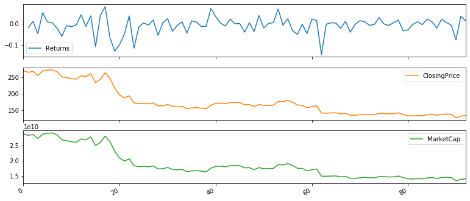

```python
figure1 = etc[["Returns", "ClosingPrice", "MarketCap"]].plot(subplots = True, figsize=(13, 6))
```

Using scraped data, we can compare the returs (or any other chosen indicator) with popularity of a cryptocurrency, basing on Google Trends.

*Initially, it was planned to gather data from Twitter and prepare a sentiment analysis of tweets about cryptocurrencies. They would be later assesed and modeled to check the influence on trading patterns on the market. As crypto market is quite speculative, it is believed that opinions of respected financial/FinTech advisiors, profressors and jurnalists might affect prices of smaller currencies. It might be an interesting subject for further studies.*

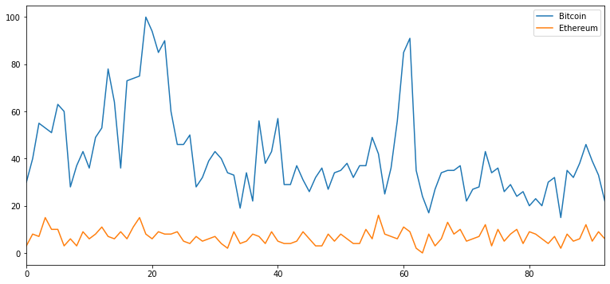

```python
trends = pd.read_csv("trends1.csv")
figure2 = trends[["Bitcoin", "Ethereum"]].plot(subplots = False, figsize=(13, 6))
```

```python
etc = pd.merge(etc, trends, left_index = True, right_index = True)
```

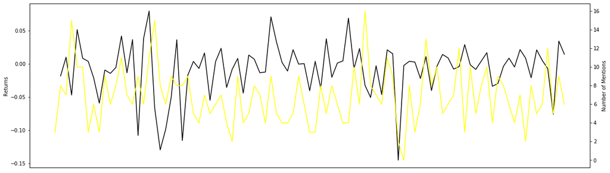

```python
fig, figure3 = plt.subplots(figsize=(20, 6))

figure4 = figure3.twinx()
figure3.plot(etc["Date_y"], etc["Returns"], color = "black")
figure4.plot(etc["Date_y"], etc["Ethereum"], color = "yellow")

figure3.set_ylabel("Returns", color = "black")
figure4.set_ylabel("Number of Mentions", color = "black")

plt.xticks([])

plt.show()
```

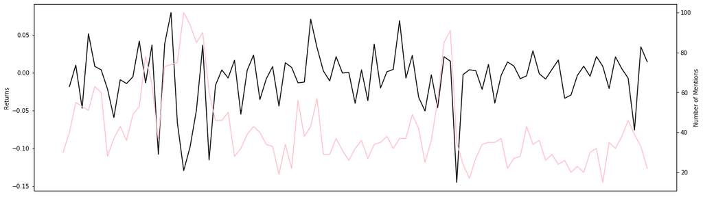

```python
fig, figure3 = plt.subplots(figsize=(20, 6))

figure4 = figure3.twinx()
figure3.plot(etc["Date_y"], etc["Returns"], color = "black")
figure4.plot(etc["Date_y"], etc["Bitcoin"], color = "pink")

figure3.set_ylabel("Returns", color = "black")
figure4.set_ylabel("Number of Mentions", color = "black")

plt.xticks([])

plt.show()
```

From simple visualization, we can see that there is some lagged relations between returns and trending key words on the Internet. It appears that there are some points, where increased number of Google searches indicated big changes in returns. Increased returns of ETC motivates *investors* to do a reasearch.

As shown above, scraped data can be used to implement more complex modeling and further predictions.